# Matching with R: Strategies for larger data

Josh Errickson

Last updated: 27 January, 2023

## Outline

1. Review of propensity scores and matching
2. Separating PS and matching
3. Introduction to `optmatch`
4. Optimal and full matching
5. Speeding up matching
6. Final example

# Review of Matching

## Overlap & Balance #1

- Overlap: Are variables observed over the same range for both groups?

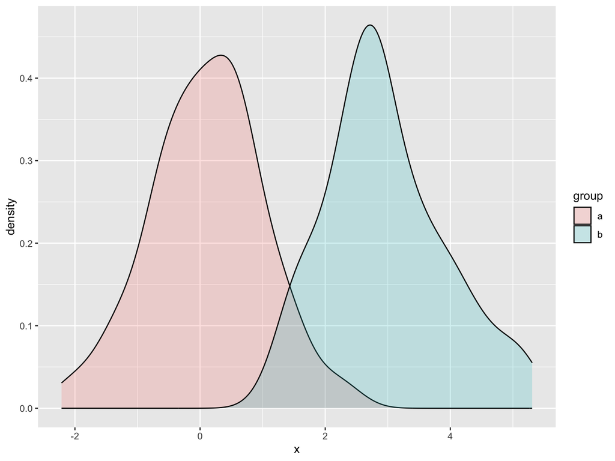

## Overlap & Balance #2

- Balance: Are the distributions of variables the same for both groups?

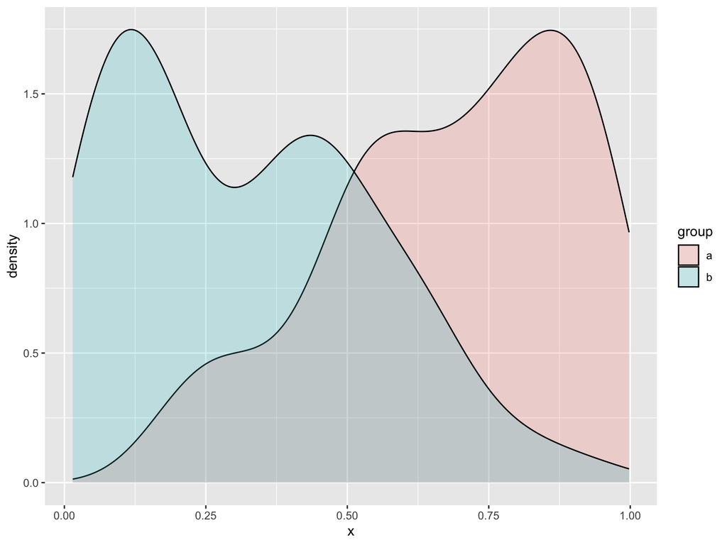

## Overlap & Balance #3

- Matching is very good at addressing *partial* overlap.
- Propensity score matching is theoretically good at addressing imbalance.
  - Practically maybe not.
- Weighting/Regression may be better at addressing imbalance solely.

## Overlap & Balance #4

- Overlap is easy to observe and quantify, and comes for “free” with matching, so usually not a focus.
- Balance is moderately hard to observe and quantify (especially in higher dimensions) and will be the focus of matching

## Love plot

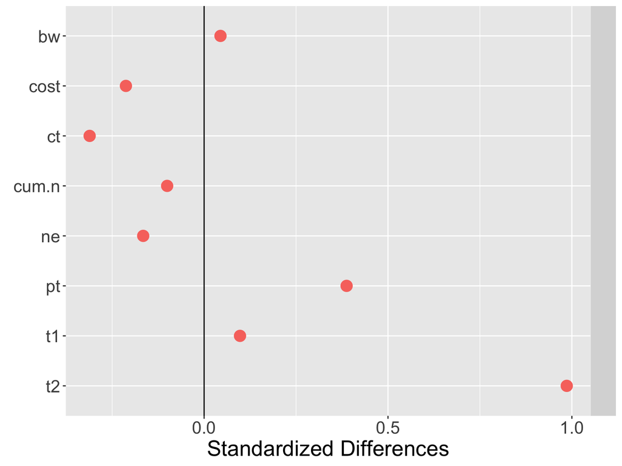

## Distance

- How “far away” are a pair of observations?
  - Easy for 1 dimension, less clear for more dimensions.
- Can define distance however you want
- Common choices:
  - Euclidean
  - Mahalanobis

## Measuring match quality

- Formal goal: Balance
  - Harder to define
  - Is often multi-dimensional
- Instead, measure total distance within a matched set
- Goal: Minimize distance in matched sets
- Strong correlation between balance and distance

## Propensity Score Matching

- Matching on more than one covariate is challenging.

$$ps_i(\mathbf{X}_i) = P(Z_i = 1 |
\mathbf{X}_i)$$

- Probability of an observation being in group 1 (usually treatment) given their characteristics.
- Propensity scores can be thought of as dimension reduction.
- Scores are usually estimated by logistic regression predicting group membership.
  - “Kitchen sink”

## Main Benefit of PS matching

- If we can …
  1. Observe the true propensity score.
  2. Have an infinitely large sample size.
  3. Can pair observations that have identical PS’s.
- … then we get covariate balance on observed *and unobserved* covariates!
- Of course, not perfect, but better than nothing.

# Separating Matching and Propensity Scores

## Matching without PS

- If small number of covariates to match on relative to sample size, and covariates have good overlap, can match directly.
- Treat PS as “just another” variable.

## PS without Matching

- Weighting
- Subsetting
- Stratafication
- Treating PS as a predictor in Regression
- …
- Each has it’s own pro’s and con’s.

# Introduction to `optmatch` and `RItools`

## `optmatch`

- Package for optimal full matching (both terms to be defined).
- Simplest form:

```r
#install.packages("optmatch")
library(optmatch)
str(d)
```

```
## 'data.frame':    11 obs. of  3 variables:
##  $ group: num  0 0 0 0 0 0 0 0 1 1 1
##  $ x1   : num  2 4 3 5 6 3 4 1 0 1 3
##  $ x2   : num  3 2 1 2 3 1 2 4 6 4 7
```

```r
d$match <- pairmatch(group ~ x1 + x2, data = d)
```

- Generates a `factor` variable identifying match membership, or `NA`.

```r
d$match
```

```
##  [1] 1.3  <NA> <NA> <NA> 1.2  <NA> <NA> 1.1  1.3  1.1  1.2
```

```r
summary(d$match)
```

```
## Structure of matched sets:
## 1:1 0:1
##   3   5
## Effective Sample Size:  3
## (equivalent number of matched pairs).
```

- Can be used in analysis, for example (not executed):

```r
lm(y ~ group + x1 + x2 + match, data = d)
lm(y ~ group + x1 + x2, data = d[!is.na(d$match), ])
lmer(y ~ group + x1 + x2 + (1|match), data = d)
```

- Note that all of the above still used `x1` and `x2` *even though we matched on them*.
  - Balance vs overlap
  - Doubly robust

## `RItools`

- A collection of useful function for randomization inference
- Most useful for `balanceTest` function
  - Checks balance and `plot`ing the result of `balanceTest` will produce a Love plot.

```r
#install.packages("RItools")
library(RItools)
baltest <- balanceTest(group ~ x1 + x2, data = d)
baltest
```

```
##      strata():        --
##      stat      Treatment Control adj.diff std.diff    z
## vars
## x1                  1.3     3.5      -2.2     -1.4    -1.8 .
## x2                  5.7     2.2      3.4       2.6     2.6 *
## ---Overall Test---
##    chisquare df p.value
## --       7.1  2   0.028
## ---
## Signif. codes:  0 '***' 0.001 '** ' 0.01 '*  ' 0.05 '.  ' 0.1 '   ' 1
```

- Null hypothesis is balance - we *don’t* want to reject!

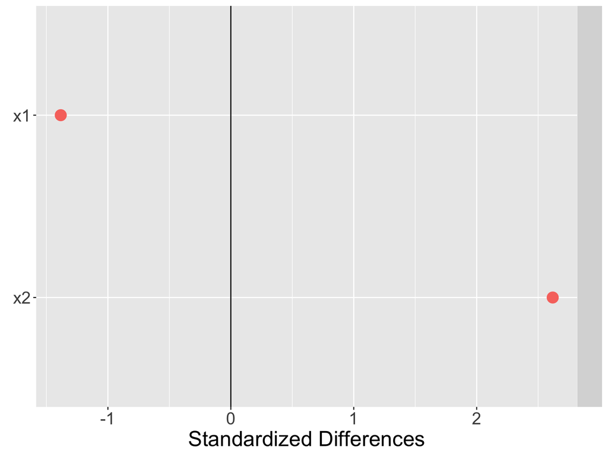

```r
plot(baltest)
```

- Now compare the unmatched data to the matched data.

```r
baltest2 <- balanceTest(group ~ x1 + x2 + strata(match), data = d)
baltest2
```

```
##      strata():     match                                               --
##      stat      Treatment Control adj.diff std.diff    z         Treatment Control adj.diff std.diff    z
## vars
## x1                  1.3     3.0      -1.7     -1.1    -1.4           1.3     3.5      -2.2     -1.4    -1.8 .
## x2                  5.7     3.3      2.3       1.8     1.4           5.7     2.2      3.4       2.6     2.6 *
## ---Overall Test---
##       chisquare df p.value
## match       2.0  2   0.368
## --          7.1  2   0.028
## ---
## Signif. codes:  0 '***' 0.001 '** ' 0.01 '*  ' 0.05 '.  ' 0.1 '   ' 1
```

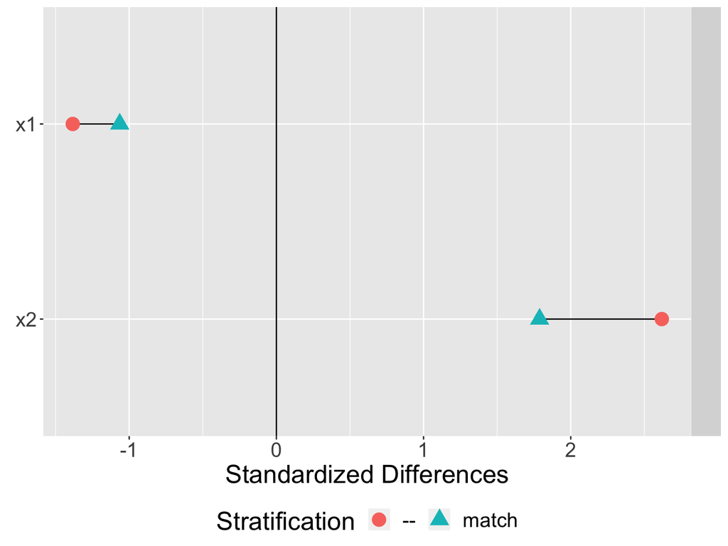

```r
plot(baltest2)
```

# Optimal and Full matching

## `j`:`k` notation

- Pair matched data is 1:1 - a single treatment to a single control.
- 1:2 would mean each treatment member shares two controls.
- 3:1 means three treatment members share a single control.
- The optimal match will have all matched sets of size `j`:`k` where either `j` = 1 or `k` = 1.

## Optimal matching

- Greedy matching matches well on first few values, but can suffer later on, while a sub-optimal early match may improve later matches.
  - Shuffle the data…
- A optimal match is equivalent to considering **all** possible matching structures.
- Optimal is a harder problem but always produces better matches
- `optmatch` package uses optimal matching.
- Distrust any method which uses greedy matching!

## 1:`k` or `j`:1 matching

- Optimal pair matching useful if sample sizes are close - easy to interpret.
- Not good if one group is much larger.
  - Loses data
- 1:`k` or `j`:1 matching allows less data loss.

## 1:`k` or `j`:1 matching in `optmatch`

- `controls` argument to `pairmatch` - # of controls per treated unit
  - 2, 3, 4, etc for 1:`k`.
  - 1/2, 1/3, 1/4, etc for `j`:1.

```r
d$match2 <- pairmatch(group ~ x1 + x2,
                      controls = 2, data = d)
d$match2
```

```
##  [1] 1.1  1.3  <NA> 1.2  1.2  <NA> 1.3  1.1  1.3  1.1  1.2
```

```r
summary(d$match2)
```

```
## Structure of matched sets:
## 1:2 0:1
##   3   2
## Effective Sample Size:  4
## (equivalent number of matched pairs).
```

```r
baltest3 <- balanceTest(group ~ x1 + x2 + strata(match2) +
                          strata(match),
                     data = d)
baltest3
```

```
##      strata():    match2                                            match                                               --
##      stat      Treatment Control adj.diff std.diff    z         Treatment Control adj.diff std.diff    z         Treatment Control adj.diff std.diff    z
## vars
## x1                  1.3     3.7      -2.3     -1.5    -2.0 .         1.3     3.0      -1.7     -1.1    -1.4           1.3     3.5      -2.2     -1.4    -1.8 .
## x2                  5.7     2.7      3.0       2.3     2.1 .         5.7     3.3      2.3       1.8     1.4           5.7     2.2      3.4       2.6     2.6 *
## ---Overall Test---
##        chisquare df p.value
## match2       4.4  2   0.112
## match        2.0  2   0.368
## --           7.1  2   0.028
## ---
## Signif. codes:  0 '***' 0.001 '** ' 0.01 '*  ' 0.05 '.  ' 0.1 '   ' 1
```

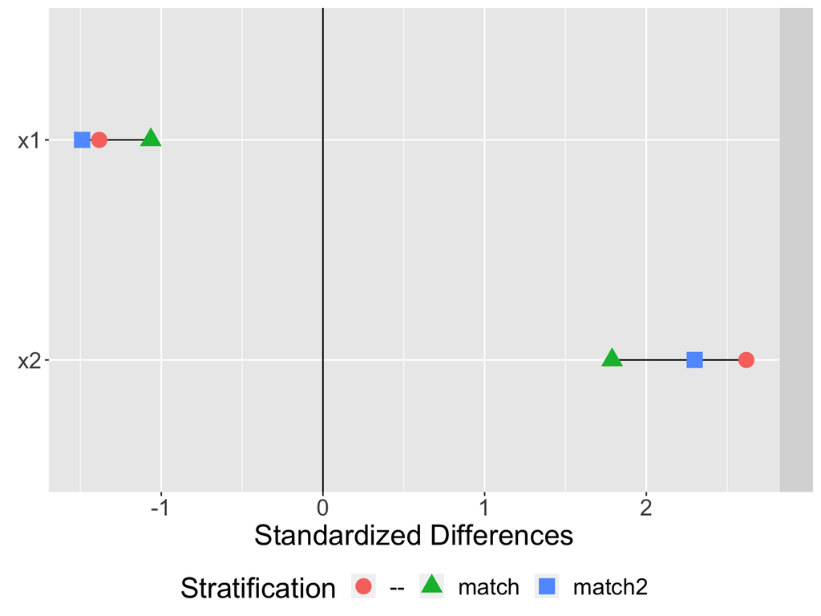

```r
plot(baltest3)
```

```r
pairmatch(group ~ x1 + x2, data = d, controls = 3)
```

```
## Error in fullmatch.matrix(x = x, min.controls = controls, max.controls = controls, : negative 'omit.fraction' with 'min.controls' >= 2 not permitted
```

## Issues with 1:`k` or `j`:1 matching

- Even with 1:`k`, can still lose up to $(n_c - k*n_t)$ data.
  - E.g., 10 treatment, 67 controls, 1:6 matching loses 7 controls.
- Can force bad matches just to meet goal. Flexibility might help.

| Treatment | Control |
| --- | --- |
| 5 | 4 |
| 10 | 5 |
|  | 6 |
|  | 11 |

| Treatment | Control |
| --- | --- |
| 5 | 4 |
| 10 | 5 |
|  | 6 |
|  | 11 |

1:2 matching:

| Treatment | Control |
| --- | --- |
| 5 | 4, 5 |
| 10 | 6, 11 |

| Treatment | Control |
| --- | --- |
| 5 | 4 |
| 10 | 5 |
|  | 6 |
|  | 11 |

Flexible matched set sizes:

| Treatment | Control | Size |
| --- | --- | --- |
| 5 | 4, 5, 6 | 1:3 |
| 10 | 11 | 1:1 |

## Fullmatching

- Allow 1:`k` or `j`:1 where `k` or `j` can vary per matched set.

```r
d$fullmatch1 <- fullmatch(group ~ x1 + x2, data = d)
summary(d$fullmatch1)
```

```
## Structure of matched sets:
##  1:1 1:5+
##    2    1
## Effective Sample Size:  3.7
## (equivalent number of matched pairs).
```

- Guaranteed to find the best possible match.
- Best may not be useful: 99:1 and 1:99.
  - Also lowers power (ESS)
- Instead we set constraints, e.g. all sets between 2:1 and 1:3.

```r
d$fullmatch2 <- fullmatch(group ~ x1 + x2,
                          max.controls = 3,
                          min.controls = 1/2,
                          data = d)
summary(d$fullmatch2)
```

```
## Structure of matched sets:
## 1:2 1:3
##   1   2
## Effective Sample Size:  4.3
## (equivalent number of matched pairs).
```

```r
baltest4 <- balanceTest(group ~ x1 + x2 + strata(fullmatch2) +
                    strata(fullmatch1) + strata(match2) +
                       strata(match), data = d)
baltest4
```

```
##      strata(): fullmatch2                                        fullmatch1                                           match2                                            match                                               --
##      stat       Treatment Control adj.diff std.diff    z          Treatment Control adj.diff std.diff    z         Treatment Control adj.diff std.diff    z         Treatment Control adj.diff std.diff    z         Treatment Control adj.diff std.diff    z
## vars
## x1                   1.3     3.7      -2.4     -1.5    -2.2 *          1.3     4.6      -3.3     -2.1    -1.8           1.3     3.7      -2.3     -1.5    -2.0 .         1.3     3.0      -1.7     -1.1    -1.4           1.3     3.5      -2.2     -1.4    -1.8 .
## x2                   5.7     2.3      3.4       2.6     2.3 *          5.7     2.4      3.3       2.5     1.8           5.7     2.7      3.0       2.3     2.1 .         5.7     3.3      2.3       1.8     1.4           5.7     2.2      3.4       2.6     2.6 *
## ---Overall Test---
##            chisquare df p.value
## fullmatch2       5.6  2   0.062
## fullmatch1       3.3  2   0.189
## match2           4.4  2   0.112
## match            2.0  2   0.368
## --               7.1  2   0.028
## ---
## Signif. codes:  0 '***' 0.001 '** ' 0.01 '*  ' 0.05 '.  ' 0.1 '   ' 1
```

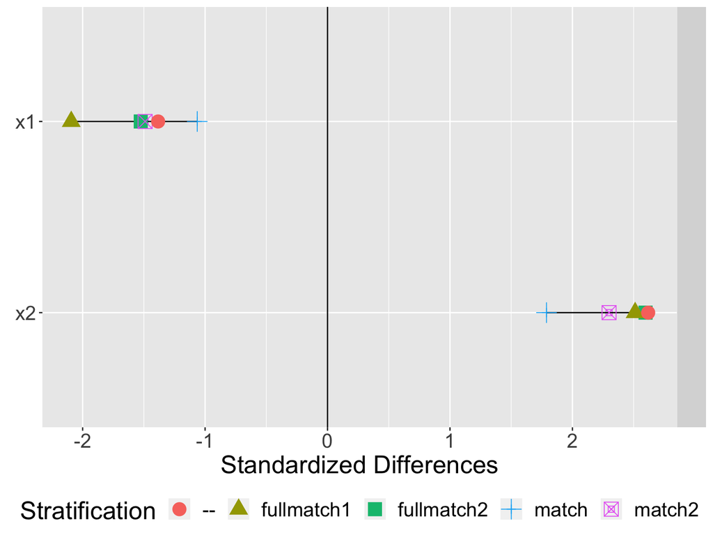

```r
plot(baltest4)
```

# Speeding up matching

## Distance Matrix

```
##    c1  c2 c3
## t1  1   0  2
## t2  4 Inf  5
```

- Each entry represents a distance.
- `0` represents identical, `Inf` represents never match.
- The more `Inf`, the faster matching will run.
- Built in `optmatch`, similar notation

```r
m1 <- match_on(group ~ x1 + x2, data = d)
m1
```

```
##          control
## treatment     1     2     3     4     5     6     7     8
##        9  2.828 4.186 4.631 4.574 4.495 4.631 4.186 1.809
##        10 1.046 2.506 2.828 2.996 3.235 2.828 2.506 0.000
##        11 3.525 4.325 5.165 4.436 3.861 5.165 4.325 2.919
```

- How do we induce `Inf` into the distance matrix?

## Exact Matching

```r
str(d)
```

```
## 'data.frame':    11 obs. of  4 variables:
##  $ group   : num  0 0 0 0 0 0 0 0 1 1 1
##  $ x1      : num  2 4 3 5 6 3 4 1 0 1 3
##  $ x2      : num  3 2 1 2 3 1 2 4 6 4 7
##  $ category: num  0 1 1 0 0 1 0 1 1 0 1
```

```r
em <- exactMatch(group ~ category, data = d)
as.matrix(em)
```

```
##        control
## treated   1   2   3   4   5   6   7   8
##      9  Inf   0   0 Inf Inf   0 Inf   0
##      10   0 Inf Inf   0   0 Inf   0 Inf
##      11 Inf   0   0 Inf Inf   0 Inf   0
```

- More useful than just adding a lot of `Inf`’s…
- … because each sub-problem can be considered its own matching problem.

```r
em
```

```
## $`0`
##        control
## treated 1 4 5 7
##      10 0 0 0 0
##
## $`1`
##        control
## treated 2 3 6 8
##      9  0 0 0 0
##      11 0 0 0 0
```

- We can combine distance matrices

```r
m1 + em
```

```
## $`0`
##        control
## treated     1     4     5     7
##      10 1.046 2.996 3.235 2.506
##
## $`1`
##        control
## treated     2     3     6     8
##      9  4.186 4.631 4.631 1.809
##      11 4.325 5.165 5.165 2.919
```

- This works for distance matricies of any format (from `match_on`, `exactMatch` or `caliper` [which we’ll see in a few slides]).
- Can be done in a single step as well:

```r
m2 <- match_on(group ~ x1 + x2, data = d, within = em)
m2
```

```
## $`0`
##        control
## treated     1     4     5     7
##      10 1.046 2.996 3.235 2.506
##
## $`1`
##        control
## treated     2     3     6     8
##      9  4.186 4.631 4.631 1.809
##      11 4.325 5.165 5.165 2.919
```

- This should be slightly faster than two separate calls.
- Now, perform matching directly on this distance.

```r
emmatch <- fullmatch(m2, data = d)
summary(emmatch)
```

```
## Structure of matched sets:
## 1:1 1:3 1:4
##   1   1   1
## Effective Sample Size:  4.1
## (equivalent number of matched pairs).
```

```r
emmatch
```

```
##   1   2   3   4   5   6   7   8   9  10  11
## 0.1 1.1 1.2 0.1 0.1 1.2 0.1 1.2 1.2 0.1 1.1
```

## Calipering

- For any pairs with large distances, we may want to either
  - Ensure they never match.
    - (Overall match may suffer, but no individual match is terrible.)
  - Speed up calculations by not checking them.

```r
as.matrix(m1)
```

```
##          control
## treatment     1     2     3     4     5     6     7     8
##        9  2.828 4.186 4.631 4.574 4.495 4.631 4.186 1.809
##        10 1.046 2.506 2.828 2.996 3.235 2.828 2.506 0.000
##        11 3.525 4.325 5.165 4.436 3.861 5.165 4.325 2.919
```

```r
c1 <- caliper(m1, width = 4)
c1
```

```
##        control
## treated 1   2   3   4   5   6   7 8
##      9  0 Inf Inf Inf Inf Inf Inf 0
##      10 0   0   0   0   0   0   0 0
##      11 0 Inf Inf Inf   0 Inf Inf 0
```

```r
m1 + c1
```

```
##        control
## treated     1     2     3     4     5     6     7     8
##      9  2.828   Inf   Inf   Inf   Inf   Inf   Inf 1.809
##      10 1.046 2.506 2.828 2.996 3.235 2.828 2.506 0.000
##      11 3.525   Inf   Inf   Inf 3.861   Inf   Inf 2.919
```

## Calipering one dimension

- Sometimes you might want to caliper only one dimension rather than overall distance - e.g. only `x1`, not the combination of `x1` and `x2`.
- Two steps process.
  1. Generate a distance matrix for `x1` and caliper it (creating a matrix of `0`’s and `Inf`’s).
  2. Generate the distance matrix for `x1` and `x2` and add it to the caliper’d matrix from step 1.
- Slightly different result than calipering overall distance.

## Combining it all

```r
mm <- match_on(group ~ x1 + x2, data = d,
               within = em, caliper = 4)
mm
```

```
## $`0`
##        control
## treated     1     4     5     7
##      10 1.046 2.996 3.235 2.506
##
## $`1`
##        control
## treated   2   3   6     8
##      9  Inf Inf Inf 1.809
##      11 Inf Inf Inf 2.919
```

- Looks like some unmatchable controls.

```r
summary(fullmatch(mm, data = d))
```

```
## Structure of matched sets:
## 2:1 1:4 0:1
##   1   1   3
## Effective Sample Size:  2.9
## (equivalent number of matched pairs).
```

- Yup, 3 unmatchable.

## Discussion

- 3-way trade-off between balance, speed and effective sample size (power).
  - More constraints on `j`:`k` leads to more power but is slower.
    - Too few constraints can limit usefulness.
    - May throw away a lot of data, negating power gain.
  - More exact matching or calipering leads to faster but less balanced matches.
    - Too many restrictions can reduce power.
    - Too few restrictions can limit usefulness.
  - Dropping observations leads to more balance matches with lower power.

# Example

## ECLS data

- Early Childhood Longitudinal Survey
- Treatment group is catholic school vs public school.

```r
dim(ecls)
```

```
## [1] 5429   21
```

```r
table(ecls$catholic)
```

```
##
##    0    1
## 4499  930
```

```r
catholic ~ race_white + race_black + race_hispanic +
  race_asian + p5numpla + p5hmage + p5hdage +
  w3momscr + w3dadscr + w3income + w3povrty +
  p5fstamp
```

| Model | Time | ESS |
| --- | --- | --- |
| Pair match | 2.39 | 930 |
| Pair match (1:2) | 7.83 | 1240 |
| Full match (unres.) | 5.14 | 1342 |
| Full match (restr.) | 101.9 | 1385 |
| Full + Exact | 3.24 | 1348 |
| PS Pair | 1.48 | 930 |
| PS Full | 1.58 | 1304 |
| PSM + Exact | 2.36 | 1300 |

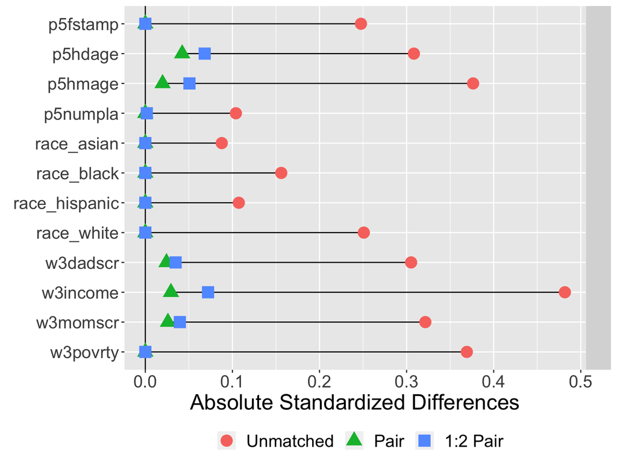

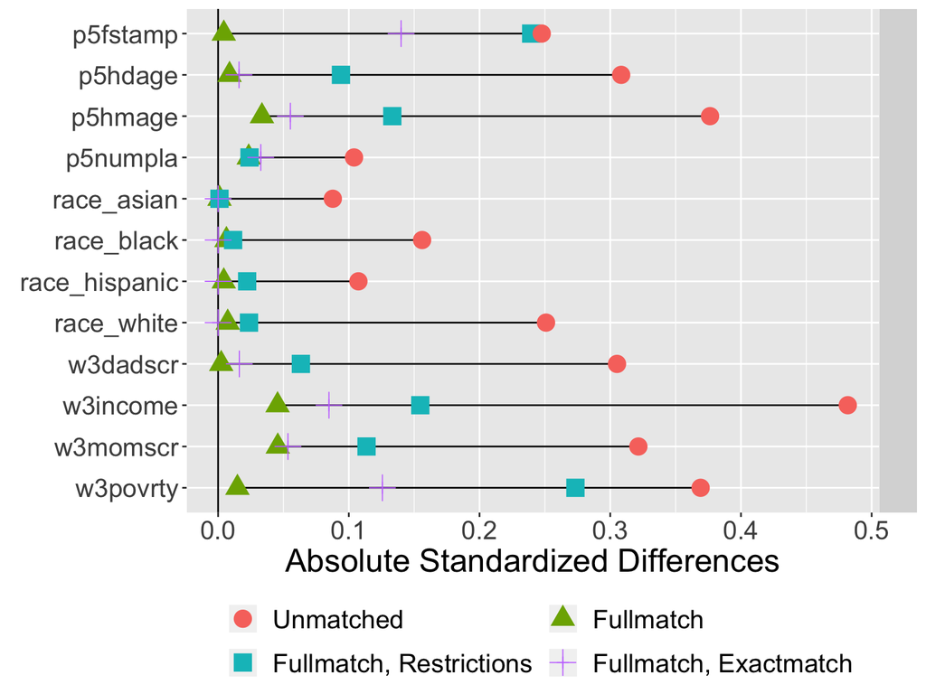

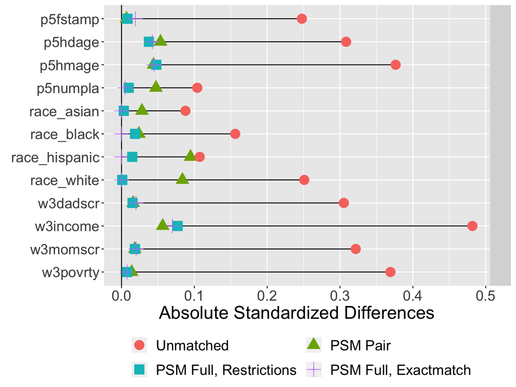

```r
lmer(c5r2mtsc ~ catholic + race_white + race_black + race_hispanic +
                race_asian + p5numpla + p5hmage + p5hdage +
                w3momscr + w3dadscr + I(w3income/10^3) + w3povrty +
                p5fstamp + (1 | match))
```

| Model | Time | ESS | Est. coef | p-value |
| --- | --- | --- | --- | --- |
| Unmatched | NA | NA | -1.48 | <.001 |
| Pair match | 2.39 | 930 | -1.51 | <.001 |
| Pair match (1:2) | 7.83 | 1240 | -1.69 | <.001 |
| Full match (unres.) | 5.14 | 1342 | -1.49 | <.001 |
| Full match (restr.) | 101.9 | 1385 | -1.48 | <.001 |
| Full + Exact | 3.24 | 1348 | -1.49 | <.001 |
| PS Pair | 1.48 | 930 | -1.63 | <.001 |
| PS Full | 1.58 | 1304 | -1.48 | <.001 |
| PSM + Exact | 2.36 | 1300 | -1.48 | <.001 |

# Other Matching Methods

- **quickmatch** - Generalized Full Matching, fast & more than two groups
- **cem** - Coarsened Exact matching, bins continuous variables and uses Exact matching
- The **MatchIt** package in R handles these and other forms of matching
  - Including **optmatch**! (But the actual **optmatch** package allows more flexiblity).